# GTFS data

Bryan Blanc

Updated as of October 01, 2020

Back to overview

# 1 Soliciting Questions for the Final Course Module

[interactive chart not shown]

# 2 Introduction

## 2.1 The General Transit Feed Specification

The [summary page for the GTFS standard](https://developers.google.com/transit/gtfs/#overview-of-a-gtfs-feed) is a good resource for more information on the standard. GTFS feeds contain many linked tables about published transit schedules about service schedules, trips, stops, and routes. Below is a diagram of these relationships and tables:

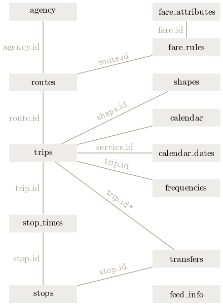

Source: Wikimedia, user -stk.

## 2.2 Read a GTFS Feed

GTFS data come packaged as a zip file of tables in text form. The first thing tidytransit does is consolidate the reading of all those tables into a single R object, which contains a list of the tables in each feed.

You can also read from any other URL. This is useful because there are many sources for GTFS data, and often the best source is transit service providers themselves. See the next section on “Finding More GTFS Feeds” for more sources of feeds.

```r
library(tidyverse)
library(sf)
library(tidytransit)
library(lubridate)
pdx <- read_gtfs("data/trimet_gtfs.zip")
```

You can use `summary` to get an overview of the feed.

```r
summary(pdx)
```

```
## GTFS object
## files        agency, calendar, routes, stops, stop_times, trips, calendar_dates, fare_attributes, fare_rules, feed_info, shapes, transfers
## agencies     TriMet, Portland Streetcar, Port of Portland
## service      from 2020-09-13 to 2020-12-05
## uses         stop_times (no frequencies)
## # routes        95
## # trips      35813
## # stop_ids    6791
## # stop_names  4669
## # shapes      1082
```

```r
head(pdx$stops)
```

```
## # A tibble: 6 x 13
##   stop_id stop_code stop_name tts_stop_name stop_desc stop_lat stop_lon zone_id
##   <chr>   <chr>     <chr>     <chr>         <chr>        <dbl>    <dbl> <chr>
## 1 2       2         A Ave & ~ ae avenue & ~ Eastboun~     45.4    -123. B
## 2 3       3         A Ave & ~ ae avenue & ~ Eastboun~     45.4    -123. B
## 3 4       4         A Ave & ~ ae avenue & ~ Westboun~     45.4    -123. B
## 4 6       6         A Ave & ~ ae avenue & ~ Eastboun~     45.4    -123. B
## 5 7       7         A Ave & ~ ae avenue & ~ Westboun~     45.4    -123. B
## 6 8       8         900 Bloc~ 900 block ab~ Eastboun~     45.4    -123. B
## # ... with 5 more variables: stop_url <chr>, location_type <int>,
## #   parent_station <chr>, direction <chr>, position <chr>
```

The tables available on each feed may vary. Below we can simply print the names of all the tables that were read in for this feed. Each of these is a table.

```r
names(pdx)
```

```
##  [1] "agency"           "calendar"         "calendar_dates"   "fare_attributes"
##  [5] "fare_rules"       "feed_info"        "routes"           "route_directions"
##  [9] "shapes"           "stops"            "stop_features"    "stop_times"
## [13] "transfers"        "trips"            "linked_datasets"
```

## 2.3 Finding GTFS Feeds

You can find current GTFS feeds through the `tidytransit` package directly as described on the [documentation website](http://tidytransit.r-transit.org/articles/introduction.html). Nevertheless, I like to browse the feeds at [transitfeeds.com](http://transitfeeds.com/), because this lets me easily browse for the specific vintage of feed that I am interested in. GTFS feeds are updated fairly often, especially for large agencies. This means that you may want to look at a previous version of the feed for your analysis, because schedules, routes, stops, or identifiers may have changed.

# 3 Understanding Service Periods

## 3.1 Overview

Each trip in a GTFS feed is referenced to a service_id (in trips.txt). The [GTFS reference](https://developers.google.com/transit/gtfs/reference/#calendartxt) specifies that a “service_id contains an ID that uniquely identifies a set of dates when service is available for one or more routes”. A service could run on every weekday or only on Saturdays for example. Other possible services run only on holidays during a year, independent of weekdays. However, feeds are not required to indicate anything with service_ids and some feeds even use a unique service_id for each trip and day. In this vignette we’ll look at a general way to gather information on when trips run by using “service patterns”.

Service patterns can be used to find a typical day for further analysis like routing or trip frequencies for different days.

## 3.2 Prepare data

```r
gtfs <- read_gtfs("data/trimet_gtfs.zip")
```

With `set_date_service_table()` we add a table to the feed that indicates which `service_id` runs on which date. This is later useful for linking dates and trips via `service_id`.

```r
gtfs <- set_date_service_table(gtfs)
head(gtfs$.$date_service_table)
```

```
## # A tibble: 6 x 2
##   date       service_id
##   <date>     <chr>
## 1 2020-11-26 X.578
## 2 2020-10-03 S.578
## 3 2020-10-10 S.578
## 4 2020-10-17 S.578
## 5 2020-10-24 S.578
## 6 2020-10-31 S.578
```

To understand service patterns better we need information on weekdays and holidays. With a calendar table we know the weekday and possible holidays for each date. We’ll use a minimal example with two holidays.

```r
holidays = tribble(~date, ~holiday,
  ymd("2018-07-04"), "Independence Day",
  ymd("2018-09-03"), "Labor Day")
calendar = tibble(date = unique(gtfs$.$date_service_table$date)) %>%
  mutate(
    weekday = (function(date) {
      c("Sunday", "Monday", "Tuesday",
        "Wednesday", "Thursday", "Friday",
        "Saturday")[as.POSIXlt(date)$wday + 1]
    })(date)
  )
calendar <- calendar %>% left_join(holidays, by = "date")
head(calendar)
```

```
## # A tibble: 6 x 3
##   date       weekday  holiday
##   <date>     <chr>    <chr>
## 1 2020-11-26 Thursday <NA>
## 2 2020-10-03 Saturday <NA>
## 3 2020-10-10 Saturday <NA>
## 4 2020-10-17 Saturday <NA>
## 5 2020-10-24 Saturday <NA>
## 6 2020-10-31 Saturday <NA>
```

To analyze on which dates trips run and to group similar services we use service patterns. Such a pattern simply lists all dates a trip runs on. For example, a trip with a pattern like *2019-03-07, 2019-03-14, 2019-03-21, 2019-03-28* runs every Thursday in March 2019. To handle these patterns we create a `servicepattern_id` using a hash function. Ideally there are the same number of servicepattern_ids and service_ids. However, in real life feeds this is rarely the case. In addition, the usability of service patterns depends largely on the feed and its complexity.

```r
gtfs <- set_servicepattern(gtfs)
```

Our gtfs feed now contains the data frame `service_pattern` which links each `servicepattern_id` to an existing `service_id` (and by extension `trip_id`).

```r
head(gtfs$.$service_pattern)
```

```
## # A tibble: 6 x 2
##   service_id servicepattern_id
##   <chr>      <chr>
## 1 1.577      s_bbb6e9d
## 2 1.578      s_911e55f
## 3 2.577      s_5b651a0
## 4 2.578      s_55fef4a
## 5 3.577      s_6e70375
## 6 3.578      s_05103f5
```

In addition, `gtfs$.$date_servicepattern_table` has been created which connects dates and service patterns (like `date_service_table`). We can compare the number of service patterns to the number of services.

```r
# service ids used
n_services <-  length(unique(gtfs$trips$service_id)) # 31
# unique date patterns
n_servicepatterns <- length(unique(gtfs$.$service_pattern$servicepattern_id)) # 16
```

The feed uses 31 service_ids but there are actually only 16 different date patterns. Other feeds might not have such low numbers, for example the [Swiss GTFS feed](https://opentransportdata.swiss/dataset/timetable-2019-gtfs) uses around 15,600 service_ids which all identify unique date patterns.

## 3.3 Analyze Data

### 3.3.1 Exploration Plot

We’ll now try to figure out usable names for those patterns. A good way to start is visualising the data.

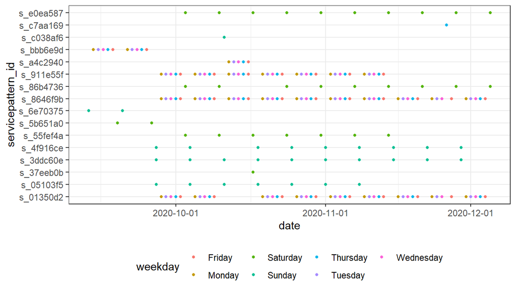

```r
date_servicepattern_table <- gtfs$.$date_servicepattern_table %>% left_join(calendar, by = "date")
ggplot(date_servicepattern_table) + theme_bw() +
  geom_point(aes(x = date, y = servicepattern_id, color = weekday), size = 1) +
  scale_x_date(breaks = scales::date_breaks("1 month")) + theme(legend.position = "bottom")
```

### 3.3.2 Names for service patterns

It’s generally difficult to automatically generate readable names for service patterns. Below you see a semi automated approach with some heuristics. However, the workflow depends largely on the feed and its structure. You might also consider setting names completely manually.

```r
suggest_servicepattern_name = function(dates, calendar) {
  servicepattern_calendar = tibble(date = dates) %>% left_join(calendar, by = "date")

  # all normal dates without holidays
  calendar_normal = servicepattern_calendar %>% filter(is.na(holiday))

  # create a frequency table for all calendar dates without holidays
  weekday_freq = sort(table(calendar_normal$weekday), decreasing = T)
  n_weekdays = length(weekday_freq)

  # all holidays that are not covered by normal weekdays anyways
  calendar_holidays <- servicepattern_calendar %>% filter(!is.na(holiday)) %>% filter(!(weekday %in% names(weekday_freq)))
  if(n_weekdays == 7) {
    pattern_name = "Every day"
  }
  # Single day service
  else if(n_weekdays == 1) {
    wd = names(weekday_freq)[1]
    # while paste0(weekday, "s") is easier, this solution can be used for other languages
    pattern_name = c("Sunday"  = "Sundays",
        "Monday"    = "Mondays",
        "Tuesday"   = "Tuesdays",
        "Wednesday" = "Wednesdays",
        "Thursday"  = "Thursdays",
        "Friday"    = "Fridays",
        "Saturday"  = "Saturdays")[wd]
  }
  # Weekday Service
  else if(n_weekdays == 5 &&
      length(intersect(names(weekday_freq),
        c("Monday", "Tuesday", "Wednesday", "Thursday", "Friday"))) == 5) {
    pattern_name = "Weekdays"
  }
  # Weekend
  else if(n_weekdays == 2 &&
      length(intersect(names(weekday_freq), c("Saturday", "Sunday"))) == 2) {
    pattern_name = "Weekends"
  }
  # Multiple weekdays that appear regularly
  else if(n_weekdays >= 2 && (max(weekday_freq) - min(weekday_freq)) <= 1) {
    wd = names(weekday_freq)
    ordered_wd = wd[order(match(wd, c("Monday", "Tuesday", "Wednesday", "Thursday", "Friday", "Saturday", "Sunday")))]
    pattern_name = paste(ordered_wd, collapse = ", ")
  }
  # default
  else {
    pattern_name = paste(weekday_freq, names(weekday_freq), sep = "x ", collapse = ", ")
  }

  # add holidays
  if(nrow(calendar_holidays) > 0) {
    pattern_name <- paste0(pattern_name, " and ", paste(calendar_holidays$holiday, collapse = ", "))
  }

  pattern_name <- paste0(pattern_name, " (", min(dates), " - ", max(dates), ")")
  return(pattern_name)
}
```

We’ll apply this function to our service patterns and create a table with ids and names.

```r
servicepattern_names = gtfs$.$date_servicepattern_table %>%
  group_by(servicepattern_id) %>% summarise(
    servicepattern_name = suggest_servicepattern_name(date, calendar)
  )
print(servicepattern_names)
```

```
## # A tibble: 16 x 2
##    servicepattern_id servicepattern_name
##    <chr>             <chr>
##  1 s_01350d2         Weekdays (2020-09-28 - 2020-12-04)
##  2 s_05103f5         Sundays (2020-09-27 - 2020-11-08)
##  3 s_37eeb0b         Saturdays (2020-10-17 - 2020-10-17)
##  4 s_3ddc60e         Sundays (2020-09-27 - 2020-11-29)
##  5 s_4f916ce         Sundays (2020-09-27 - 2020-11-29)
##  6 s_55fef4a         Saturdays (2020-10-03 - 2020-11-14)
##  7 s_5b651a0         Saturdays (2020-09-19 - 2020-09-26)
##  8 s_6e70375         Sundays (2020-09-13 - 2020-09-20)
##  9 s_8646f9b         Weekdays (2020-09-28 - 2020-12-04)
## 10 s_86b4736         Saturdays (2020-10-03 - 2020-12-05)
## 11 s_911e55f         Weekdays (2020-09-28 - 2020-11-13)
## 12 s_a4c2940         Weekdays (2020-10-12 - 2020-10-16)
## 13 s_bbb6e9d         Weekdays (2020-09-14 - 2020-09-25)
## 14 s_c038af6         Sundays (2020-10-11 - 2020-10-11)
## 15 s_c7aa169         Thursdays (2020-11-26 - 2020-11-26)
## 16 s_e0ea587         Saturdays (2020-10-03 - 2020-12-05)
```

## 3.4 Visualise services

### 3.4.1 Plot calendar for each service pattern

We can plot the service pattern like a calendar to visualise the different patterns. The original services can be plotted similarly (given it’s not too many) by using `date_service_table` and `service_id`.

```r
dates = gtfs$.$date_servicepattern_table
dates$wday <- lubridate::wday(dates$date, label = T, abbr = T, week_start = 7)
dates$week_nr <- lubridate::week(dates$date)
dates <- dates %>% group_by(week_nr) %>% summarise(week_first_date = min(date)) %>% right_join(dates, by = "week_nr")
```

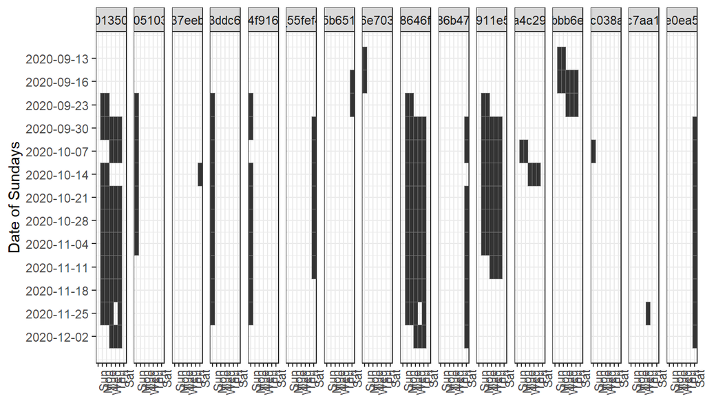

```r
week_labels = dates %>% select(week_nr, week_first_date) %>% unique()
ggplot(dates) + theme_bw() +
  geom_tile(aes(x = wday, y = week_nr), color = "#747474") +
  scale_x_discrete(drop = F) +
  scale_y_continuous(trans = "reverse", labels = week_labels$week_first_date, breaks = week_labels$week_nr) +
  theme(legend.position = "bottom", axis.text.x = element_text(angle = 90, hjust = 1)) +
  labs(x = NULL, y = "Date of Sundays") +
  facet_wrap(~servicepattern_id, nrow = 1)
```

### 3.4.2 Plot number of trips per day as calendar

We can plot the number of trips for each day as a calendar heat map.

```r
trips_servicepattern = left_join(select(gtfs$trips, trip_id, service_id), gtfs$.$service_pattern, by = "service_id")
trip_dates = left_join(gtfs$.$date_servicepattern_table, trips_servicepattern, by = "servicepattern_id")
trip_dates_count = trip_dates %>% group_by(date) %>% summarise(count = dplyr::n())
```

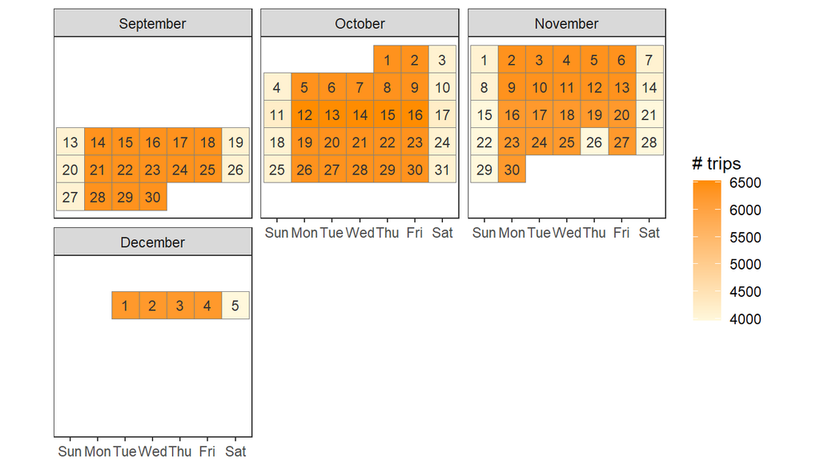

```r
trip_dates_count$weekday <- lubridate::wday(trip_dates_count$date, label = T, abbr = T, week_start = 7)
trip_dates_count$day_of_month <- lubridate::day(trip_dates_count$date)
trip_dates_count$first_day_of_month <- lubridate::wday(trip_dates_count$date - trip_dates_count$day_of_month,  week_start = 7)
trip_dates_count$week_of_month <- ceiling((trip_dates_count$day_of_month - as.numeric(trip_dates_count$weekday) - trip_dates_count$first_day_of_month) / 7)
trip_dates_count$month <- lubridate::month(trip_dates_count$date, label = T, abbr = F)
ggplot(trip_dates_count, aes(x = weekday, y = -week_of_month)) + theme_bw() +
  geom_tile(aes(fill = count, colour = "grey50")) +
  geom_text(aes(label = day_of_month), size = 3, colour = "grey20") +
  facet_wrap(~month, ncol = 3) +
  scale_fill_gradient(low = "cornsilk1", high = "DarkOrange", na.value="white")+
    scale_color_manual(guide = F, values = "grey50") +
  theme(axis.text.y = element_blank(), axis.ticks.y = element_blank()) +
  theme(panel.grid = element_blank()) +
  labs(x = NULL, y = NULL, fill = "# trips") +
  coord_fixed()
```

# 4 Reference Materials